# Projet Fierthé

KOUASSI KONAN LEGER

2025-09-02

## Plan de la Présentation

1. **Introduction et Objectifs**
2. **Statistiques Descriptives**
3. **Préparation des Données**
4. **Méthodologie : Régression Quantile**
5. **Résultats par Région**
6. **Conclusions et Recommandations**

## 1. Introduction et Objectifs

### Contexte

- Analyse du marché mondial du thé
- Compréhension des facteurs de prix
- Différenciation par régions géographiques

### Objectifs

- Identifier les déterminants du prix du thé
- Analyser les variations par quantiles de prix
- Comparer les marchés régionaux

## 2. Statistiques Descriptives

### Aperçu Global des Données

```r
# Nettoyage de l'environnement
rm(list = ls())
```

```r
# Installation et chargement des packages nécessaires
if (!require("ggrepel")) install.packages("ggrepel")
library(readxl)
library(tidyverse)
library(dplyr)
library(lubridate)
library(wordcloud)
library(tidytext)
library(scales)
library(ggplot2)
library(gganimate)
library(gridExtra)
library(ggrepel)
library(forcats)

# Importation des données
df <- readRDS("df_final.rds")
```

## 2. Statistiques Descriptives

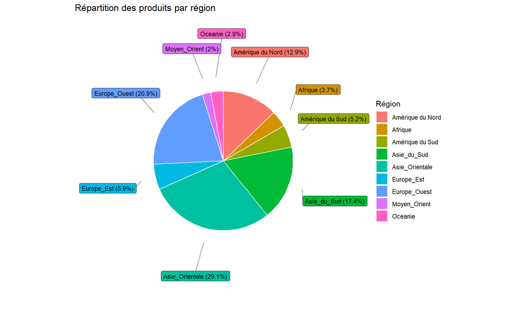

```r
region_pie <- df %>%
  filter(!is.na(Region_Marche)) %>%
  count(Region_Marche) %>%
  mutate(
    pct = n / sum(n) * 100,
    label = paste0(Region_Marche, " (", round(pct, 1), "%)"),
    ymax = cumsum(pct),
    ymin = lag(ymax, default = 0),
    label_pos = (ymin + ymax) / 2
  )

ggplot(region_pie, aes(ymax = ymax, ymin = ymin, xmax = 1, xmin = 0, fill = Region_Marche)) +
  geom_rect(color = "white") +
  coord_polar(theta = "y") +
  geom_label_repel(
    aes(x = 1.2, y = label_pos, label = label),
    size = 3,
    nudge_x = 0.5,
    show.legend = FALSE,
    segment.color = "grey50"
  ) +
  labs(
    title = "Répartition des produits par région",
    fill = "Région"
  ) +
  theme_void()
```

```r
rm(region_pie)
```

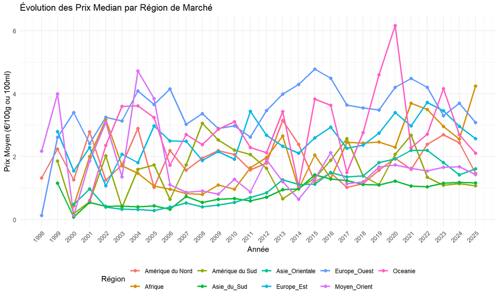

```r
# Calcul des prix moyens par année et par région de marché
gnpd <- df
prix_par_annee_region_marche <- gnpd %>%
  mutate(annee = year(`Date Published`),
         month = floor_date(`Date Published`, "month")) %>%
  filter(!is.na(`Price per 100 g/ml in Euros`),
         !is.na(annee),
         !is.na(Region_Marche)) %>%
  group_by(annee, Region_Marche) %>%
  summarise(
    n = n(),
    prix_moyen = mean(`Price per 100 g/ml in Euros`, na.rm = TRUE),
    prix_median = median(`Price per 100 g/ml in Euros`, na.rm = TRUE)
  ) %>%
  arrange(annee, Region_Marche)

# Graphique de l'évolution des prix moyens par région de marché
ggplot(prix_par_annee_region_marche,
       aes(x = annee, y = prix_median, color = Region_Marche, group = Region_Marche)) +
  geom_line(size = 1) +
  geom_point(size = 2) +
  labs(
    title = "Évolution des Prix Median par Région de Marché",
    x = "Année",
    y = "Prix Moyen (€/100g ou 100ml)",
    color = "Région"
  ) +
  theme_minimal() +
  scale_x_continuous(breaks = seq(min(prix_par_annee_region_marche$annee),
                                max(prix_par_annee_region_marche$annee), by = 1)) +
  theme(axis.text.x = element_text(angle = 45, hjust = 1),
        legend.position = "bottom")
```

```r
rm(gnpd,prix_par_annee_region_marche)
```

### Évolution des Lancements dans le Temps

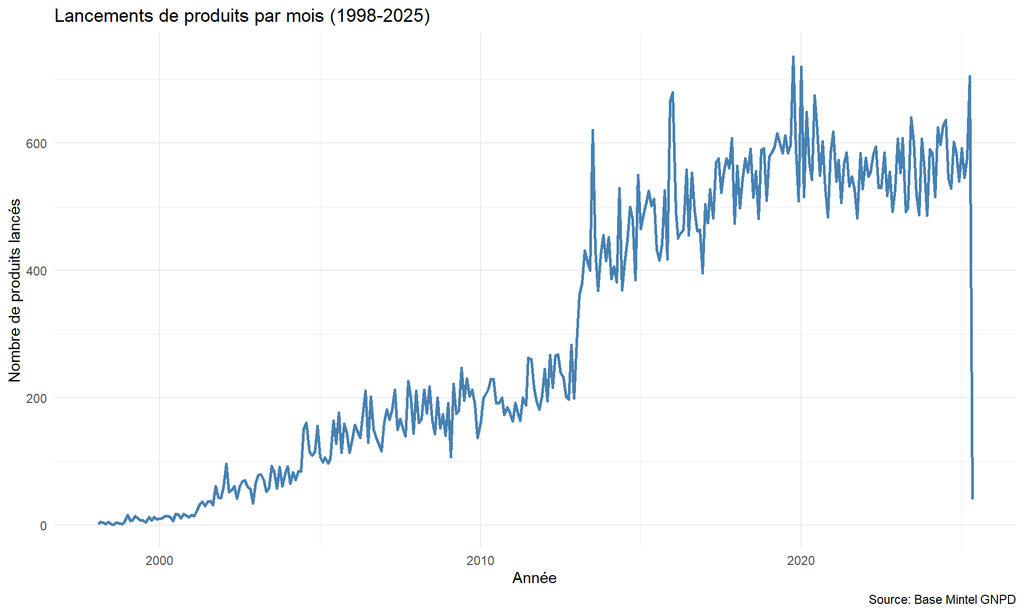

```r
# Nombre de lancements par mois
df %>%
  count(month) %>%
  ggplot(aes(x = month, y = n)) +
  geom_line(color = "steelblue", size = 1) +
  labs(title = "Lancements de produits par mois (1998-2025)",
       x = "Année",
       y = "Nombre de produits lancés",
       caption = "Source: Base Mintel GNPD") +
  theme_minimal()
```

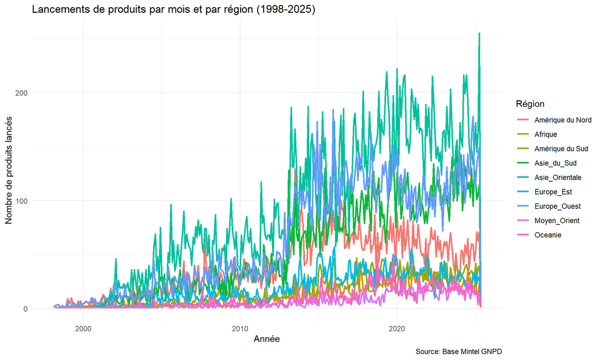

```r
df %>%
  count(month, Region_Marche) %>%
  ggplot(aes(x = month, y = n, color = Region_Marche)) +
  geom_line(size = 1) +
  labs(title = "Lancements de produits par mois et par région (1998-2025)",
       x = "Année",
       y = "Nombre de produits lancés",
       color = "Région",
       caption = "Source: Base Mintel GNPD") +
  theme_minimal()
```

```r
  #scale_color_brewer(palette = "Set2")  # Pour de belles couleurs distinctes
```

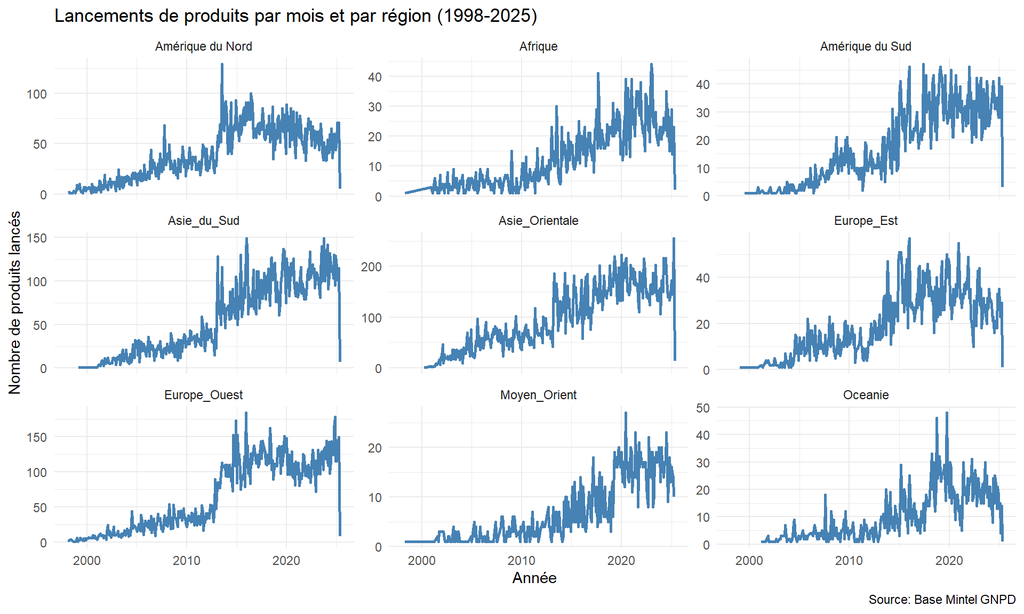

```r
df %>%
  count(month, Region_Marche) %>%
  ggplot(aes(x = month, y = n)) +
  geom_line(color = "steelblue", size = 1) +
  facet_wrap(~ Region_Marche, scales = "free_y") +  # ou scales = "fixed" selon votre besoin
  labs(title = "Lancements de produits par mois et par région (1998-2025)",
       x = "Année",
       y = "Nombre de produits lancés",
       caption = "Source: Base Mintel GNPD") +
  theme_minimal()
```

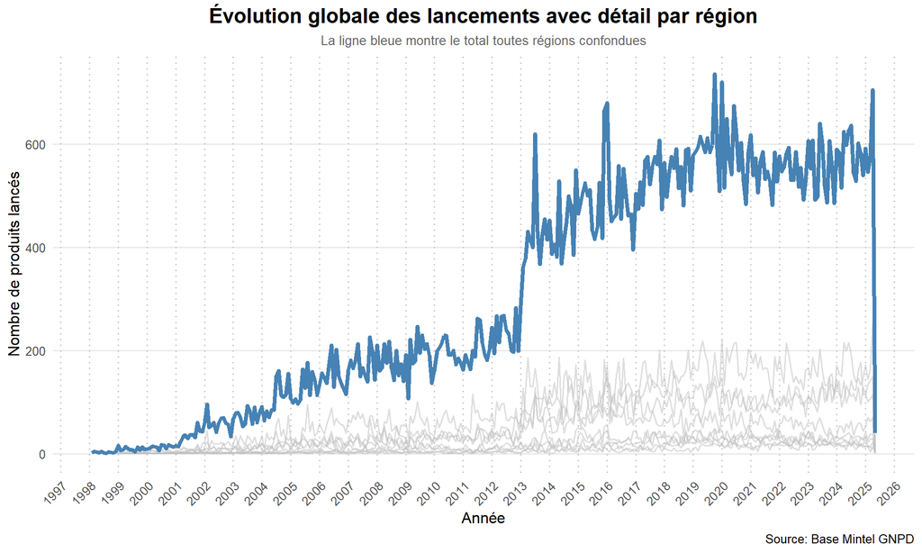

```r
df %>%
  # Calculer les totaux par région
  count(month, Region_Marche) %>%
  # Calculer le total global
  group_by(month) %>%
  mutate(total = sum(n)) %>%
  ggplot() +
  # Lignes pour chaque région (en transparence)
  geom_line(aes(x = month, y = n, group = Region_Marche),
            color = "gray", alpha = 0.5, size = 0.7) +
  # Ligne pour le total global (plus visible)
  geom_line(aes(x = month, y = total),
            color = "steelblue", size = 1.5) +
  scale_x_date(date_breaks = "1 year", date_labels = "%Y")+
  labs(title = "Évolution globale des lancements avec détail par région",
       subtitle = "La ligne bleue montre le total toutes régions confondues",
       x = "Année",
       y = "Nombre de produits lancés",
       caption = "Source: Base Mintel GNPD") +
  theme_minimal(base_size = 12)+
  scale_y_continuous(limits = c(0, NA), labels = comma) +  # Échelle Y qui commence à 0
  theme_minimal(base_size = 12) +
  theme(
    plot.title = element_text(face = "bold", size = 16, hjust = 0.5),
    plot.subtitle = element_text(size = 10, hjust = 0.5, color = "grey40"),
    panel.grid.minor = element_blank(),
    panel.grid.major.x = element_line(linetype = "dotted", color = "grey80"),
    axis.text.x = element_text(angle = 45, hjust = 1)
  )
```

## Focus sur les entreprises

```r
# Compter les lancements par entreprise et trier
entreprises <- df %>%
  count(Company, name = "Nb_Lancements") %>%
  arrange(desc(Nb_Lancements))


entreprises_tea <- df %>%
  filter(`Sub-Category` == "Tea") %>%
  count(Company, name = "Nb_Lancements") %>%
  arrange(desc(Nb_Lancements))

# Garder les top 20 entreprises
top_entreprises <- entreprises %>%
  slice_head(n = 20)
top_entreprises_tea <- entreprises_tea %>%
  slice_head(n= 20)

# Filtrer celles avec un min de lancements
entreprises_significatives <- entreprises %>%
  filter(Nb_Lancements >= 50)
```

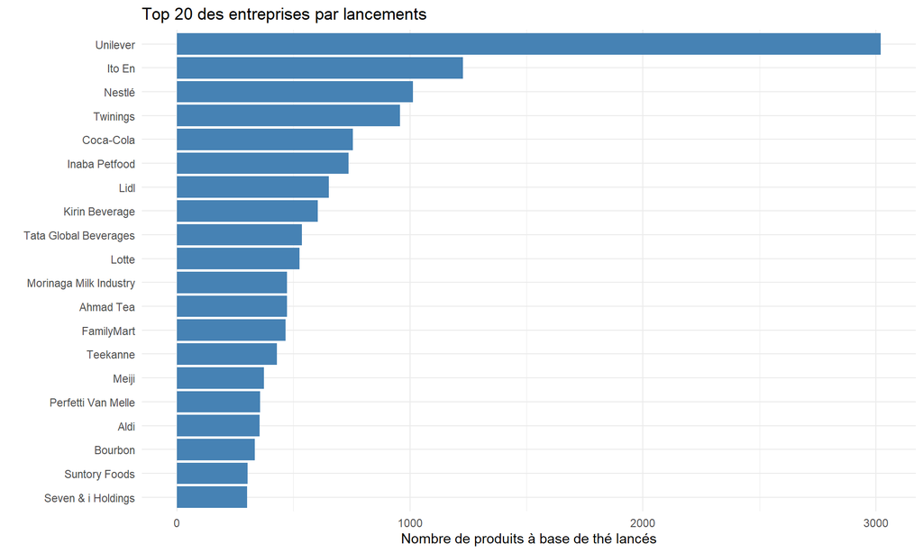

```r
top_entreprises %>%
  mutate(Company = fct_reorder(Company, Nb_Lancements)) %>%
  ggplot(aes(x = Nb_Lancements, y = Company)) +
  geom_col(fill = "steelblue") +
  labs(title = "Top 20 des entreprises par lancements",
       x = "Nombre de produits à base de thé lancés",
       y = "") +
  theme_minimal()
```

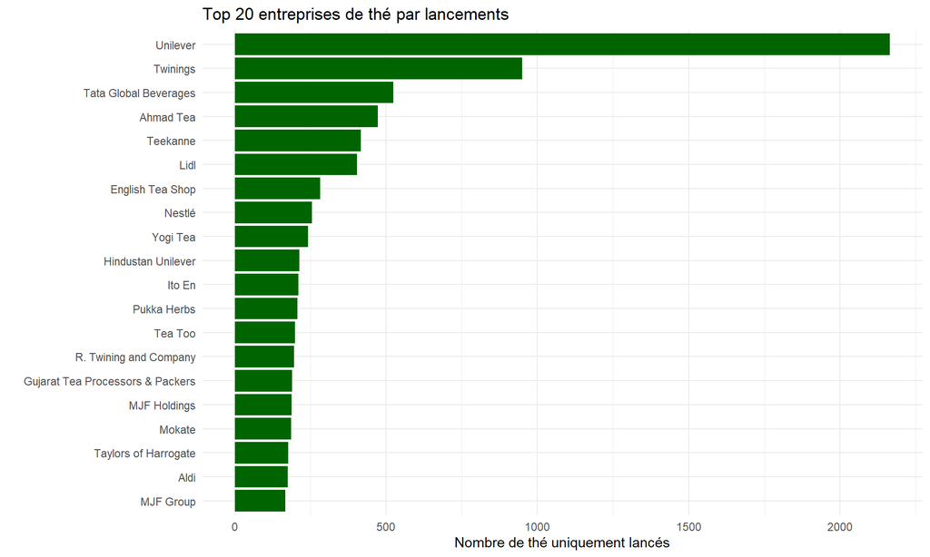

```r
## thé
top_entreprises_tea %>%
  mutate(Company = fct_reorder(Company, Nb_Lancements)) %>%
  ggplot(aes(x = Nb_Lancements, y = Company)) +
  geom_col(fill = "darkgreen") +
  labs(title = "Top 20 entreprises de thé par lancements",
       x = "Nombre de thé uniquement lancés",
       y = "") +
  theme_minimal()
```

```r
rm(top_entreprises,top_entreprises_tea,entreprises_significatives,entreprises,
   entreprises_tea)
```

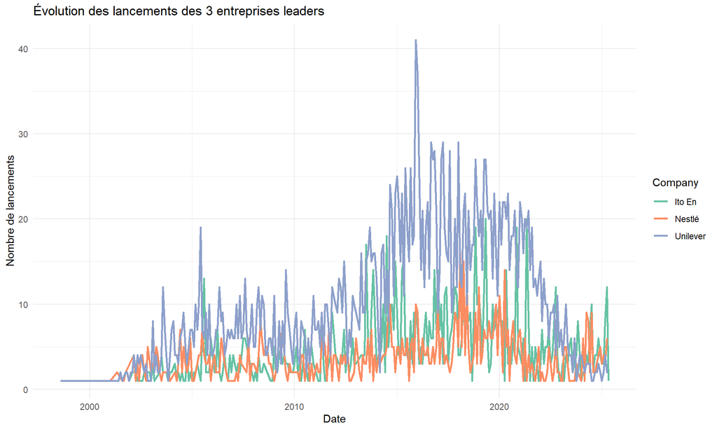

```r
library(dplyr)
library(lubridate)

# Agrégation par mois
df_temporel <- df %>%
  count(month, name = "Nb_Lancements")

# Identifier les 10 entreprises les plus actives
top_10 <- df %>%
  count(Company, name = "Nb_Lancements") %>%
  slice_max(Nb_Lancements, n = 3) %>%
  pull(Company)

# Filtrer et agréger
df_top10 <- df %>%
  filter(Company %in% top_10) %>%
  count(month, Company, name = "Nb_Lancements")

# Visualisation multi-lignes
ggplot(df_top10, aes(x = month, y = Nb_Lancements, color = Company)) +
  geom_line(linewidth = 1) +
  labs(title = "Évolution des lancements des 3 entreprises leaders",
       x = "Date", y = "Nombre de lancements") +
  theme_minimal() +
  scale_color_brewer(palette = "Set2")
```

```r
rm(df_temporel,df_top10,top_10)
```

Ces graphiques montrent clairement que l’entreprise “Unilever” domine clairement le marché du thé dans le monde.

## Focus sur les dynamiques d’entreprises

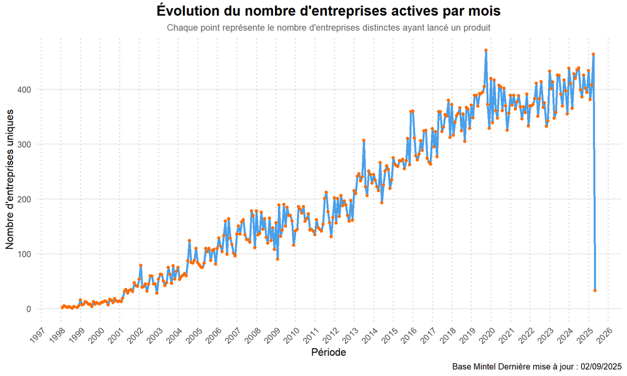

```r
library(ggplot2)
library(dplyr)
library(scales)  # Pour les formats de date/échelle

df %>%
  group_by(month) %>%
  summarise(Nb_Entreprises = n_distinct(Company)) %>%
  ggplot(aes(x = month, y = Nb_Entreprises)) +
  # Éléments visuels améliorés
  geom_line(color = "#1E88E5", size = 1.2, alpha = 0.8) +  # Bleu plus professionnel
  geom_point(color = "#FF6D00", size = 1.5) +  # Points orange pour marquer les observations
  # Mise en forme avancée
  scale_x_date(date_breaks = "1 year", date_labels = "%Y") +  # Format des dates
  scale_y_continuous(limits = c(0, NA), labels = comma) +  # Échelle Y qui commence à 0
  # Labels et thème améliorés
  labs(
    title = "Évolution du nombre d'entreprises actives par mois",
    subtitle = "Chaque point représente le nombre d'entreprises distinctes ayant lancé un produit",
    x = "Période",
    y = "Nombre d'entreprises uniques",
    caption = paste("Base Mintel Dernière mise à jour :", format(Sys.Date(), "%d/%m/%Y"))
  ) +
  theme_minimal(base_size = 12) +
  theme(
    plot.title = element_text(face = "bold", size = 16, hjust = 0.5),
    plot.subtitle = element_text(size = 10, hjust = 0.5, color = "grey40"),
    panel.grid.minor = element_blank(),
    panel.grid.major.x = element_line(linetype = "dotted", color = "grey80"),
    axis.text.x = element_text(angle = 45, hjust = 1)
  )
```

Ce graphique nous permet dire que le nombre de produit lancés est correlé avec le nombre d’entreprise presente sur le marché.

```r
library(plotly)
library(dplyr)

# Préparation des données
plot_data <- df %>%
  group_by(month) %>%
  summarise(Nb_Entreprises = n_distinct(Company))

# Création du graphique interactif
plot <- plot_ly(plot_data, x = ~month) %>%
  add_lines(
    y = ~Nb_Entreprises,
    line = list(color = "#1E88E5", width = 3),
    name = "Entreprises actives",
    hoverinfo = "text",
    text = ~paste(
      "<b>Date:</b> ", format(month, "%B %Y"), "<br>",
      "<b>Entreprises uniques:</b> ", Nb_Entreprises
    )
  ) %>%
  add_markers(
    y = ~Nb_Entreprises,
    marker = list(color = "#FF6D00", size = 6),
    name = "Observation",
    showlegend = FALSE
  ) %>%
  layout(
    title = list(
      text = "<b>Évolution du nombre d'entreprises actives par mois</b>",
      x = 0.05,
      font = list(size = 18)
    ),
    xaxis = list(
      title = "Période",
      type = "date",
      tickformat = "%Y",
      tickangle = 45,
      gridcolor = "#f0f0f0"
    ),
    yaxis = list(
      title = "Nombre d'entreprises uniques",
      zeroline = FALSE,
      gridcolor = "#f0f0f0"
    ),
    hoverlabel = list(
      bgcolor = "white",
      font = list(family = "Arial", size = 12)
    ),
    plot_bgcolor = "white",
    paper_bgcolor = "white",
    margin = list(l = 50, r = 50, t = 80, b = 80),
    annotations = list(
      list(
        x = 0.5,
        y = -0.2,
        text = paste("Dernière mise à jour :", format(Sys.Date(), "%d/%m/%Y")),
        showarrow = FALSE,
        xref = "paper",
        yref = "paper",
        font = list(size = 10, color = "grey")
      )
    )
  ) %>%
  add_annotations(
    text = "Source: Base Mintel GNPD",
    x = 1,
    y = -0.25,
    xref = "paper",
    yref = "paper",
    showarrow = FALSE,
    font = list(size = 10, color = "grey")
  )

# Personnalisation de la légende
plot <- plot %>% layout(
  legend = list(
    orientation = "h",
    x = 0.5,
    y = -0.1,
    xanchor = "center"
  )
)

# Affichage du graphique
plot
```

[interactive chart not shown]

```r
rm(plot_data,plot)
```

```r
rm(top_entreprises,top_entreprises_tea,top_10,entreprises,entreprises_significatives,entreprises_tea,df_temporel,df_top10,prix_par_annee_region_marche, plot_data, plot)
```

```r
library(dplyr)

# Compter les entreprises uniques par territoire
entreprises_par_pays <- df %>%
  filter(!is.na(`Company Territory`),
         !is.na(Company)) %>%
  distinct(`Company Territory`, Company) %>%  # Éviter les doublons
  count(`Company Territory`, sort = TRUE) %>%
  rename(Nombre_Entreprises = n)

# Afficher les 10 premiers
head(entreprises_par_pays, 10)
```

| Company Territory | Nombre_Entreprises |
| --- | --- |
| China | 2763 |
| USA | 1976 |
| India | 1207 |
| South Korea | 961 |
| Germany | 727 |
| UK | 709 |
| Taiwan | 642 |
| Thailand | 629 |
| France | 623 |
| Japan | 588 |

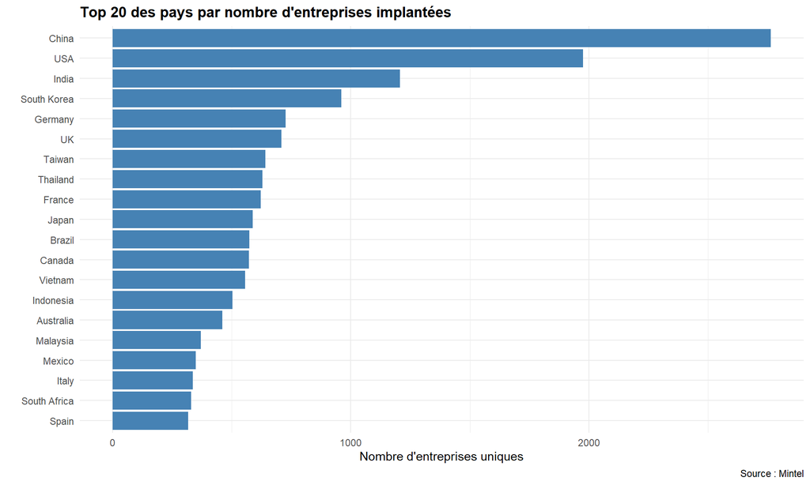

```r
library(ggplot2)

# Garder les top 20 pays pour une meilleure lisibilité
top_pays <- entreprises_par_pays %>%
  slice_max(Nombre_Entreprises, n = 20) %>%
  mutate(`Company Territory` = fct_reorder(`Company Territory`, Nombre_Entreprises))

ggplot(top_pays, aes(x = Nombre_Entreprises, y = `Company Territory`)) +
  geom_col(fill = "steelblue") +
  labs(title = "Top 20 des pays par nombre d'entreprises implantées",
       x = "Nombre d'entreprises uniques",
       y = "",
       caption = "Source : Mintel") +
  theme_minimal() +
  theme(plot.title = element_text(face = "bold"))
```

```r
library(plotly)

plot_ly(top_pays,
        x = ~Nombre_Entreprises,
        y = ~reorder(`Company Territory`, Nombre_Entreprises),
        type = 'bar',
        orientation = 'h',
        marker = list(color = '#1f77b4'),
        hoverinfo = 'text',
        text = ~paste('Pays: ', `Company Territory`,
                     '<br>Entreprises: ', Nombre_Entreprises)) %>%
  layout(title = "Implantation des entreprises par pays",
         xaxis = list(title = "Nombre d'entreprises"),
         yaxis = list(title = ""))
```

[interactive chart not shown]

```r
rm(entreprises_par_pays,top_pays)
```

## Focus sur la France

```r
library(plotly)
library(dplyr)

df %>%
  filter(Company == "Unilever",
         `Company Territory` == 'France') %>%
  distinct(`Company address`)
```

| Company address |
| --- |
| Rueil Malmaison |
| Saint Ouen |
| NA |
| Antony |
| Levallois-Perret |

```r
# 1. Filtrage des entreprises avec ≥3 adresses distinctes
implantations_filtrees <- df %>%
  filter(`Company Territory` == "France",
         !is.na(`Company address`)) %>%
  distinct(Company, `Company address`) %>%
  count(Company, sort = TRUE) %>%
  slice_max(n, n = 20) %>%
  mutate(Company = fct_reorder(Company, n))

head(implantations_filtrees,n=10)
```

| Company | n |
| --- | --- |
| Unilever | 4 |
| Alter Eco | 3 |
| Contrex | 3 |
| Interdis | 3 |
| La Route des Comptoirs | 3 |
| Lobodis | 3 |
| Omega Pharma | 3 |
| Pagès | 3 |
| Affinity Petcare | 2 |
| Aldi | 2 |

Ce tableau nous présente les entreprises les plus implanté en France.

```r
# Top 20 entreprises actives sur le marché français
top_acteurs <- df %>%
  filter(Market == "France") %>%
  count(Company, name = "Nb_Produits", sort = TRUE) %>%
  slice_max(Nb_Produits, n = 20) %>%
  mutate(Company = fct_reorder(Company, Nb_Produits))

# Visualisation interactive
plot_ly(top_acteurs,
        x = ~Nb_Produits,
        y = ~Company,
        type = 'bar',
        orientation = 'h',
        marker = list(color = '#E15759'),
        hoverinfo = 'text',
        text = ~paste('Entreprise: ', Company,
                     '<br>Produits lancés: ', Nb_Produits)) %>%
  layout(title = list(text = "<b>TOP 20 des acteurs du marché français</b><br>",
                     x = 0.05),
         xaxis = list(title = "Nombre de produits lancés"),
         yaxis = list(title = ""),
         margin = list(l = 150))
```

[interactive chart not shown]

```r
rm(french_dominance,top_acteurs,implantations_filtrees)
```

```r
# Entreprises françaises dominantes à l'international
library(plotly)
library(dplyr)

# Préparation des données
french_dominance <- df %>%
  filter(`Company Territory` == "France") %>%
  count(Market, name = "Nb_Produits") %>%
  arrange(desc(Nb_Produits)) %>%
  mutate(Market = ifelse(row_number() <= 10, as.character(Market), "Autre")) %>%
  group_by(Market) %>%
  summarize(Nb_Produits = sum(Nb_Produits)) %>%
  arrange(desc(Nb_Produits)) %>%
  mutate(Market = factor(Market, levels = Market))  # Préserver l'ordre

# Visualisation optimisée
plot_ly(french_dominance,
        labels = ~Market,
        values = ~Nb_Produits,
        type = 'pie',
        textinfo = 'percent',  # Afficher seulement le pourcentage dans le graphique
        hoverinfo = 'label+text+percent',
        hovertext = ~paste('Marché:', Market, '<br>Produits:', Nb_Produits),
        textposition = 'inside',  # Place le texte à l'intérieur des sections
        textfont = list(size = 12),
        insidetextorientation = 'radial',  # Améliore la lisibilité
        marker = list(
          colors = RColorBrewer::brewer.pal(10, "Set2"),
          line = list(color = '#FFFFFF', width = 1)  # Bordures blanches
        ),
        hole = 0.4  # Donut chart pour plus d'espace
) %>%
layout(
  title = list(
    text = "<b>Marchés cibles des entreprises implantées en  France</b>",
    x = 0.5,  # Centrer le titre
    y = 0.95,  # Ajuster la position verticale
    xanchor = 'center',
    font = list(size = 18)
  ),
  legend = list(
    orientation = 'v',  # Légende verticale
    x = 1.1,  # Décaler à droite
    y = 0.5,
    font = list(size = 10)
  ),
  margin = list(
    l = 50,  # Marge gauche
    r = 150,  # Marge droite augmentée pour la légende
    b = 50,   # Marge basse
    t = 100,  # Marge haute
    pad = 5    # Padding interne
  ),
  showlegend = TRUE,
  annotations = list(
    list(
      text = "Source: Mintel GNPD",
      x = 0.5,
      y = -0.1,
      xref = "paper",
      yref = "paper",
      showarrow = FALSE,
      font = list(size = 10, color = "grey")
    )
  )
) %>%
config(displayModeBar = T)  # Flase pour masquer la barre d'outils pour plus de lisibilité
```

[interactive chart not shown]

```r
rm(french_dominance)
```

## 2. Statistiques Descriptives

### Top Marchés de Lancement

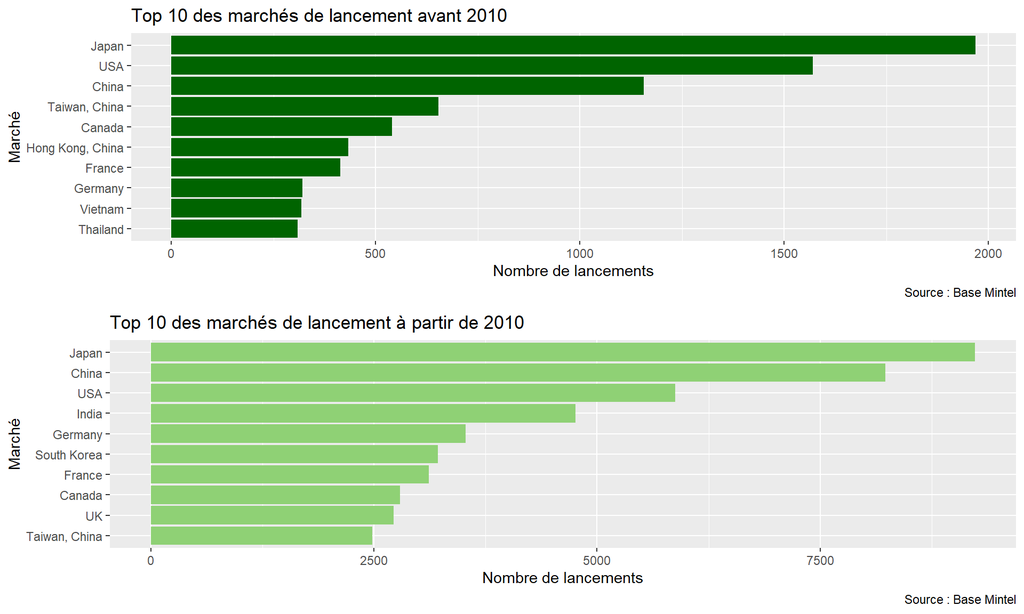

```r
# Top 10 des marchés de lancement
p1 <- df %>%
  filter(year < 2010) %>%
  count(Market, sort = TRUE) %>%
  slice_max(n, n = 10) %>%
  ggplot(aes(x = reorder(Market, n), y = n)) +
  geom_col(fill = "darkgreen") +
  coord_flip() +
  labs(title = "Top 10 des marchés de lancement avant 2010",
       x = "Marché",
       y = "Nombre de lancements",
       caption = "Source : Base Mintel")

p2 <- df %>%
  filter(year >= 2010) %>%
  count(Market, sort = TRUE) %>%
  slice_max(n, n = 10) %>%
  ggplot(aes(x = reorder(Market, n), y = n)) +
  geom_col(fill = "#8fd175") +
  coord_flip() +
  labs(title = "Top 10 des marchés de lancement à partir de 2010",
       x = "Marché",
       y = "Nombre de lancements",
       caption = "Source : Base Mintel")

grid.arrange(p1, p2, ncol = 1)
```

```r
rm(p1,p2)
```

Ces deux graphiques nous montrent la dynamique du lancement de nouveau produit avant et apres 2010 au niveau des top 10 de marché de lancement. Il s’agit ici du cumul des produits lancés sur ces deux periodes.

## 2. Statistiques Descriptives

### Répartition par Famille de Produits

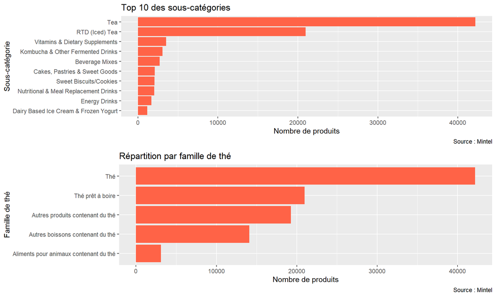

```r
# Répartition des sous-catégories
p1 <- df %>%
  count(`Sub-Category`, sort = TRUE) %>%
  slice_max(n, n = 10) %>%
  ggplot(aes(x = reorder(`Sub-Category`, n), y = n)) +
  geom_col(fill = "tomato") +
  coord_flip() +
  labs(title = "Top 10 des sous-catégories",
       x = "Sous-catégorie",
       y = "Nombre de produits",
       caption = "Source : Mintel")

p2 <- df %>%
  count(`Famille thé`, sort = TRUE) %>%
  ggplot(aes(x = reorder(`Famille thé`, n), y = n)) +
  geom_col(fill = "tomato") +
  coord_flip() +
  labs(title = "Répartition par famille de thé",
       x = "Famille de thé",
       y = "Nombre de produits",
       caption = "Source : Mintel")

grid.arrange(p1, p2, ncol = 1)
```

```r
rm(p1,p2)
```

Le premier graphique nous permet de voir sous categorie à base de thé les plus representées. Le thé brut est de loin le plus répresenté dans cette base suivie du thé glacé. Pour Mieux prendre en compte l’ensemble des sous catégories, nous les avons regroupé en 5 grandes familles. C’est qui nous montre le deuxieme graphique c’est à dire la repartition des ces familles en fonction des produits lancés de 1998 à 2025.

## 2. Statistiques Descriptives

### Évolution des Lancements par Famille

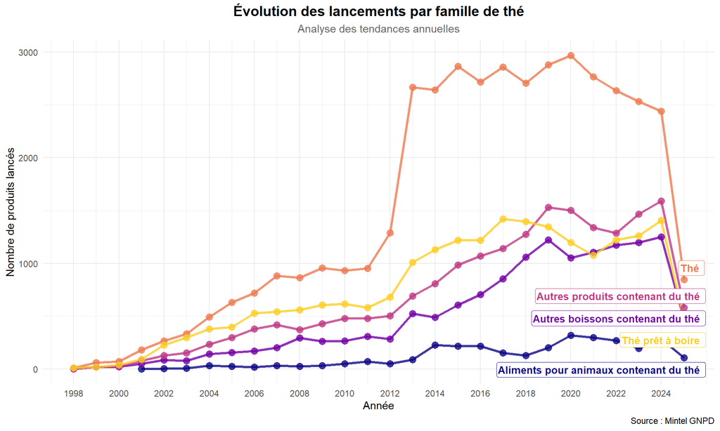

```r
# Évolution annuelle par famille de thé
evolution_data <- df %>%
  count(year, `Famille thé`) %>%
  group_by(`Famille thé`) %>%
  mutate(
    last_year = (year == max(year)),
    label = if_else(last_year, `Famille thé`, NA_character_)
  )

ggplot(evolution_data, aes(x = year, y = n, color = `Famille thé`, group = `Famille thé`)) +
  geom_line(linewidth = 1.2, alpha = 0.8) +
  geom_point(size = 3, alpha = 0.8) +
  geom_label_repel(
    aes(label = label),
    na.rm = TRUE,
    hjust = 0,
    direction = "y",
    segment.color = NA,
    size = 3.5,
    fontface = "bold",
    show.legend = FALSE
  ) +
  scale_x_continuous(breaks = seq(min(evolution_data$year), max(evolution_data$year), by = 2)) +
  scale_color_viridis_d(option = "plasma", end = 0.9) +
  labs(
    title = "Évolution des lancements par famille de thé",
    subtitle = "Analyse des tendances annuelles",
    x = "Année",
    y = "Nombre de produits lancés",
    caption = "Source : Mintel GNPD"
  ) +
  theme_minimal() +
  theme(
    legend.position = "none",
    plot.title = element_text(face = "bold", size = 14, hjust = 0.5),
    plot.subtitle = element_text(hjust = 0.5, color = "gray40")
  )
```

```r
rm(evolution_data)
```

## Focus sur le marché français

[figure not shown]

```r
# Répartition des sous-catégories
p1 <- df %>%
  filter(Market == "France") %>%
  count(`Sub-Category`, sort = TRUE) %>%
  slice_max(n, n = 10) %>%
  ggplot(aes(x = reorder(`Sub-Category`, n), y = n)) +
  geom_col(fill = "tomato") +
  coord_flip() +
  labs(title = "Top 10 des sous-catégories sur le marché français",
       x = "Sous-catégorie",
       y = "Nombre de produits",
       caption = "Source : Mintel")

p2 <- df %>%
  filter(Market == "France") %>%
  count(`Famille thé`, sort = TRUE) %>%
  ggplot(aes(x = reorder(`Famille thé`, n), y = n)) +
  geom_col(fill = "tomato") +
  coord_flip() +
  labs(title = "Répartition par famille de thé sur le marché français",
       x = "Famille de thé",
       y = "Nombre de produits",
       caption = "Source : Mintel")

grid.arrange(p1, p2, ncol = 1)
```

```r
rm(p1,p2)
################################################################################
```

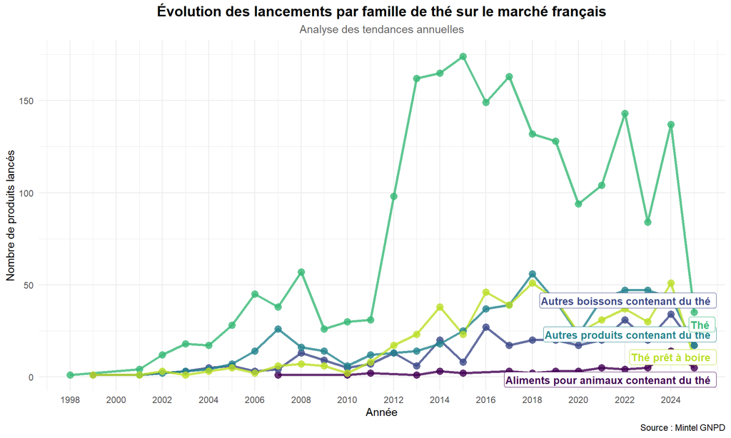

```r
# Évolution annuelle par famille de thé
evolution_data <- df %>%
  filter(Market== "France") %>%
  count(year, `Famille thé`) %>%
  group_by(`Famille thé`) %>%
  mutate(
    last_year = (year == max(year)),
    label = if_else(last_year, `Famille thé`, NA_character_)
  )

ggplot(evolution_data, aes(x = year, y = n, color = `Famille thé`, group = `Famille thé`)) +
  geom_line(linewidth = 1.2, alpha = 0.8) +
  geom_point(size = 3, alpha = 0.8) +
  geom_label_repel(
    aes(label = label),
    na.rm = TRUE,
    hjust = 0,
    direction = "y",
    segment.color = NA,
    size = 3.5,
    fontface = "bold",
    show.legend = FALSE
  ) +
  scale_x_continuous(breaks = seq(min(evolution_data$year), max(evolution_data$year), by = 2)) +
  scale_color_viridis_d(option = "D", end = 0.9) +
  labs(
    title = "Évolution des lancements par famille de thé sur le marché français",
    subtitle = "Analyse des tendances annuelles",
    x = "Année",
    y = "Nombre de produits lancés",
    caption = "Source : Mintel GNPD"
  ) +
  theme_minimal() +
  theme(
    legend.position = "none",
    plot.title = element_text(face = "bold", size = 14, hjust = 0.5),
    plot.subtitle = element_text(hjust = 0.5, color = "gray40")
  )
```

```r
rm(evolution_data)
```

## 2. Statistiques Descriptives (suite)

### Analyse des Prix

```r
summary(df$`Price per 100 g/ml in Euros`)
```

```
##     Min.  1st Qu.   Median     Mean  3rd Qu.     Max.     NA's
##    0.000    0.430    1.680    5.523    5.850 2959.260     6031
```

```r
summary(df %>%
          filter(`Price per 100 g/ml in Euros`!=0) %>%
          select(`Price per 100 g/ml in Euros`))
```

```
##  Price per 100 g/ml in Euros
##  Min.   :   0.010
##  1st Qu.:   0.430
##  Median :   1.680
##  Mean   :   5.524
##  3rd Qu.:   5.850
##  Max.   :2959.260
```

```r
# Nettoyage des données de prix (99% des produits)
#df <- df %>% filter(`Price per 100 g/ml in Euros` != 0)
df_clean <- df %>%
  filter(!is.na(`Price per 100 g/ml in Euros`),
         `Price per 100 g/ml in Euros` < quantile(`Price per 100 g/ml in Euros`, 0.99, na.rm = TRUE))

# Statistiques descriptives des prix
price_stats <- df_clean %>%
  summarise(
    min_price = min(`Price per 100 g/ml in Euros`, na.rm = TRUE),
    mean_price = mean(`Price per 100 g/ml in Euros`, na.rm = TRUE),
    median_price = median(`Price per 100 g/ml in Euros`, na.rm = TRUE),
    max_price = max(`Price per 100 g/ml in Euros`, na.rm = TRUE),
    sd_price = sd(`Price per 100 g/ml in Euros`, na.rm = TRUE),
    n = n()
  )

print(price_stats)
```

```
## # A tibble: 1 × 6
##   min_price mean_price median_price max_price sd_price     n
##       <dbl>      <dbl>        <dbl>     <dbl>    <dbl> <int>
## 1         0       4.58         1.64      53.0     7.11 92641
```

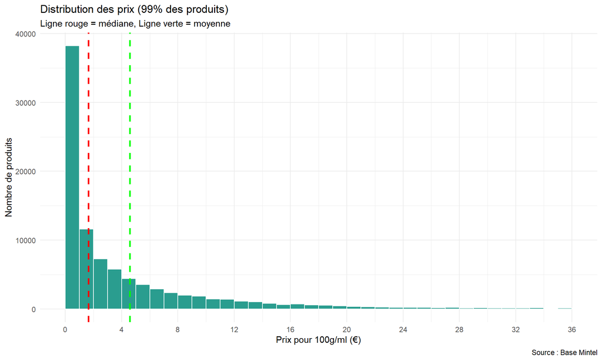

```r
# Distribution des prix
ggplot(df_clean, aes(x = `Price per 100 g/ml in Euros`)) +
  geom_histogram(fill = "#2a9d8f", color = "white", boundary = 0, binwidth = 1) +
  geom_vline(xintercept = median(df_clean$`Price per 100 g/ml in Euros`, na.rm = TRUE),
             color = "red", linetype = "dashed", size = 1) +
  geom_vline(xintercept = mean(df_clean$`Price per 100 g/ml in Euros`, na.rm = TRUE),
             color = "green", linetype = "dashed", size = 1) +
  coord_cartesian(xlim = c(0, 36)) +
  scale_x_continuous(breaks = seq(0, 36, 4)) +
  labs(
    title = "Distribution des prix (99% des produits)",
    subtitle = "Ligne rouge = médiane, Ligne verte = moyenne",
    x = "Prix pour 100g/ml (€)",
    y = "Nombre de produits",
    caption = "Source : Base Mintel"
  ) +
  theme_minimal()
```

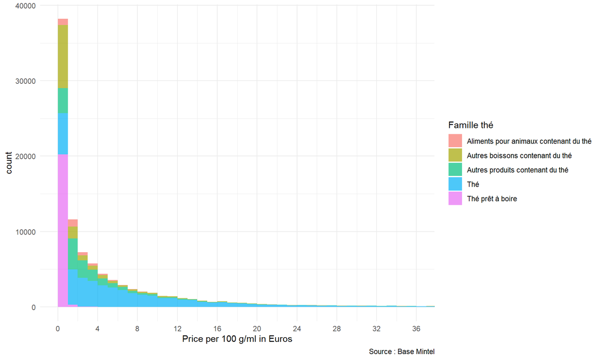

```r
# Le prix en fonction des sous categories en faisant un Zoom sur 0-20€
ggplot(df_clean, aes(x = `Price per 100 g/ml in Euros`, fill = `Famille thé`)) +
  geom_histogram(binwidth = 1, alpha = 0.7,boundary=0) +
  coord_cartesian(xlim = c(0, 36))+
  scale_x_continuous(breaks = seq(0, 36, 4)) +
  labs(
    caption = "Source : Base Mintel"
  ) +
  theme_minimal()
```

```r
rm(price_stats)
```

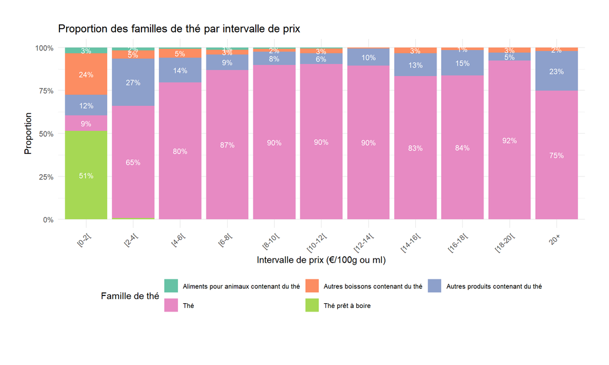

```r
library(ggplot2)
library(dplyr)
library(scales)

# 1. Créer les intervalles de prix
df_clean <- df_clean %>%
  mutate(
    price_interval = cut(`Price per 100 g/ml in Euros`,
                        breaks = c(0, 2, 4, 6, 8, 10, 12, 14, 16, 18, 20, Inf),
                        labels = c("[0-2[", "[2-4[", "[4-6[", "[6-8[", "[8-10[",
                                 "[10-12[", "[12-14[", "[14-16[", "[16-18[", "[18-20[", "20+"),
                        right = FALSE)
  )

# 2. Calculer les proportions
df_prop <- df_clean %>%
  filter(Market=="France") %>%
  count(price_interval, `Famille thé`) %>%
  group_by(price_interval) %>%
  mutate(prop = n / sum(n)) %>%
  ungroup()

# 3. Diagramme empilé à 100% avec légende complète
ggplot(df_prop, aes(x = price_interval, y = prop, fill = `Famille thé`)) +
  geom_col(position = "fill") +
  geom_text(aes(label = ifelse(prop > 0.01, percent(prop, accuracy = 1), "")),
            position = position_fill(vjust = 0.5),
            size = 3, color = "white") +
  scale_y_continuous(labels = percent_format()) +
  scale_fill_brewer(palette = "Set2",
                   guide = guide_legend(nrow = 2, byrow = TRUE)) + # Légende sur 2 lignes
  labs(
    title = "Proportion des familles de thé par intervalle de prix",
    x = "Intervalle de prix (€/100g ou ml)",
    y = "Proportion",
    fill = "Famille de thé"
  ) +
  theme_minimal() +
  theme(
    axis.text.x = element_text(angle = 45, hjust = 1, vjust = 1),
    legend.position = "bottom",
    legend.box = "horizontal",
    plot.margin = margin(1, 1, 2, 1, "cm"), # Augmente les marges
    legend.text = element_text(size = 8) # Réduit la taille du texte
  )
```

```r
rm(df_prop)
```

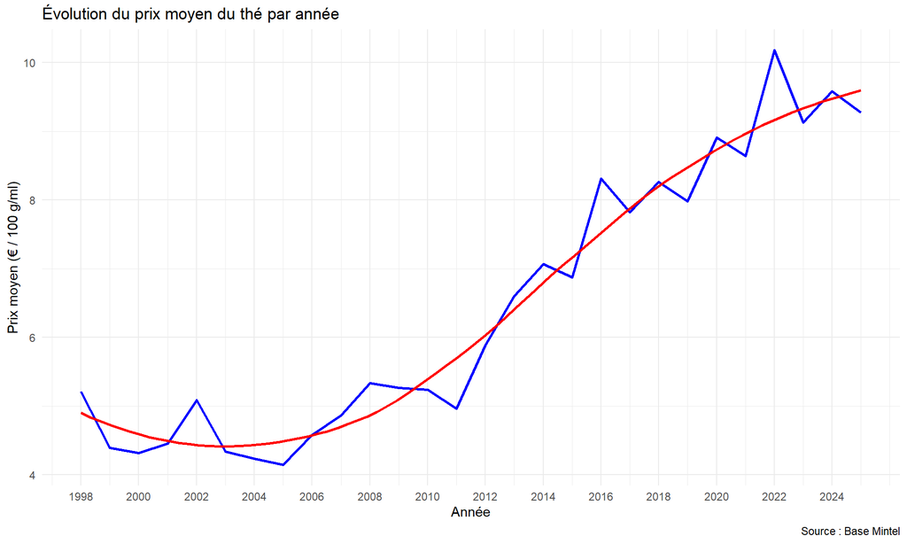

```r
library(lubridate)
library(dplyr)


# Creation de la variable mois
prix_par_mois <- df_clean %>%
  filter(!is.na(`Price per 100 g/ml in Euros`),
         `Sub-Category` == "Tea") %>%
  mutate(
    last_year = (year == max(year)),
    label = if_else(last_year, `Famille thé`, NA_character_)
  ) %>%
  group_by(year) %>%
  summarise(Prix_moyen = mean(`Price per 100 g/ml in Euros`))


# Representation graphique
library(ggplot2)

ggplot(prix_par_mois, aes(x = year, y = Prix_moyen)) +
  geom_line(color = "blue", size = 1) +
  #geom_point(color = "darkblue", size = 1.5) +
  geom_smooth(method = "loess", color = "red", se = FALSE) +
  scale_x_continuous(breaks = seq(min(df$year), max(df$year), by = 2)) +
  labs(title = "Évolution du prix moyen du thé par année",
       x = "Année",
       y = "Prix moyen (€ / 100 g/ml)",
       caption = "Source : Base Mintel") +
  theme_minimal()
```

```r
rm(prix_par_mois)
```

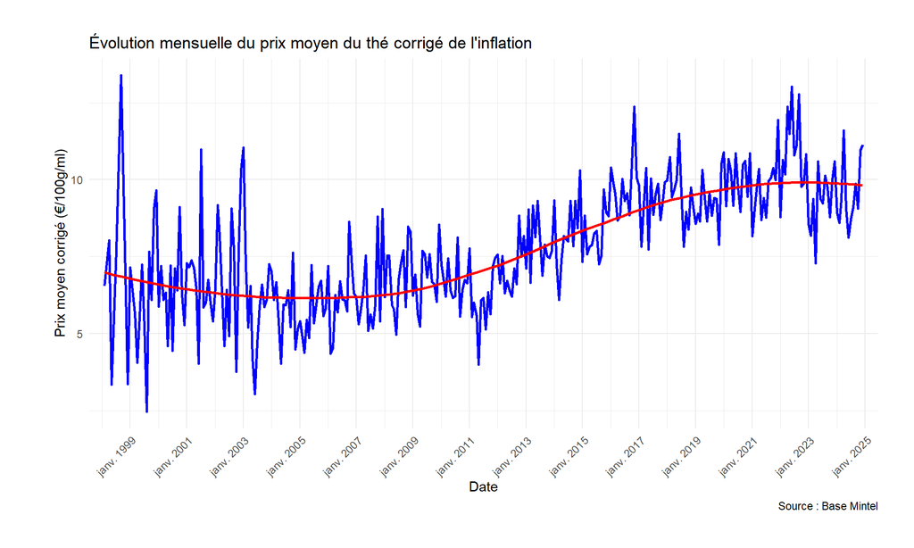

```r
library(lubridate)
library(dplyr)


# Creation de la variable mois
prix_par_mois <- df_clean %>%
  filter(!is.na(Prix_corrige),
         `Sub-Category` == "Tea") %>%
  mutate(
    last_year = (year == max(month)),
    label = if_else(last_year, `Famille thé`, NA_character_)
  ) %>%
  group_by(month) %>%
  summarise(Prix_moyen = mean(Prix_corrige))


# Representation graphique
library(ggplot2)

ggplot(prix_par_mois, aes(x = month, y = Prix_moyen)) +
  geom_line(color = "blue", size = 1) +
  #geom_point(color = "darkblue", size = 1.5) +
  geom_smooth(method = "loess", color = "red", se = FALSE) +
  #scale_x_continuous(breaks = seq(min(df$month), max(df$month), by = 12)) +
  scale_x_date(
    date_labels = "%b %Y",        # Format "Jan 2000"
    date_breaks = "2 year",       # Un tick par an
    expand = c(0.02, 0.02)        # Réduire les marges
  ) +
  labs(
    title = "Évolution mensuelle du prix moyen du thé corrigé de l'inflation",
    x = "Date",
    y = "Prix moyen corrigé (€/100g/ml)",
    caption = "Source : Base Mintel"
  ) +
  theme_minimal() +
  theme(
    axis.text.x = element_text(angle = 45, hjust = 1),
    plot.margin = margin(1, 1, 1, 1.5, "cm")
  )
```

```r
rm(prix_par_mois)
```

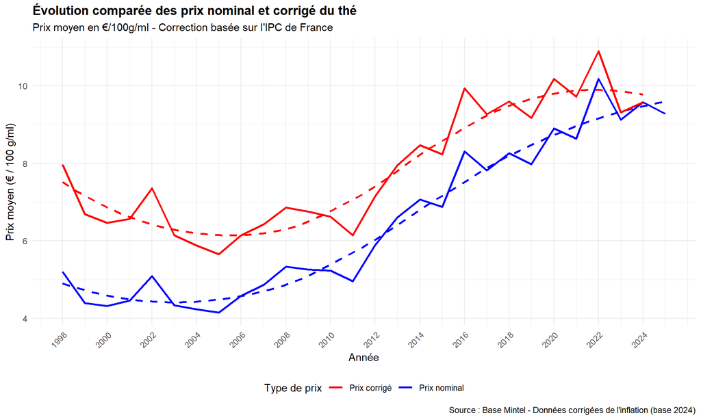

```r
library(lubridate)
library(dplyr)
library(ggplot2)

# Préparation des données avec prix corrigé et non corrigé
prix_par_mois <- df_clean %>%
  filter(!is.na(`Price per 100 g/ml in Euros`),
         `Sub-Category` == "Tea") %>%
  group_by(year) %>%
  summarise(
    Prix_moyen = mean(`Price per 100 g/ml in Euros`),
    Prix_corrige_moyen = mean(Prix_corrige, na.rm = TRUE)
  )

# Représentation graphique avec deux échelles
ggplot(prix_par_mois) +
  # Prix non corrigé (nominal)
  geom_line(aes(x = year, y = Prix_moyen, color = "Prix nominal"), size = 1) +
  geom_smooth(aes(x = year, y = Prix_moyen, color = "Prix nominal"),
              method = "loess", se = FALSE, linetype = "dashed") +

  # Prix corrigé (réel)
  geom_line(aes(x = year, y = Prix_corrige_moyen, color = "Prix corrigé"), size = 1) +
  geom_smooth(aes(x = year, y = Prix_corrige_moyen, color = "Prix corrigé"),
              method = "loess", se = FALSE, linetype = "dashed") +

  # Mise en forme
  scale_x_continuous(breaks = seq(min(prix_par_mois$year),
                     max(prix_par_mois$year), by = 2)) +
  scale_color_manual(
    name = "Type de prix",
    values = c("Prix nominal" = "blue", "Prix corrigé" = "red")
  ) +
  labs(
    title = "Évolution comparée des prix nominal et corrigé du thé",
    subtitle = "Prix moyen en €/100g/ml - Correction basée sur l'IPC de France",
    x = "Année",
    y = "Prix moyen (€ / 100 g/ml)",
    caption = "Source : Base Mintel - Données corrigées de l'inflation (base 2024)"
  ) +
  theme_minimal() +
  theme(
    legend.position = "bottom",
    plot.title = element_text(face = "bold"),
    axis.text.x = element_text(angle = 45, hjust = 1)
  )
```

```r
rm(prix_par_mois)
```

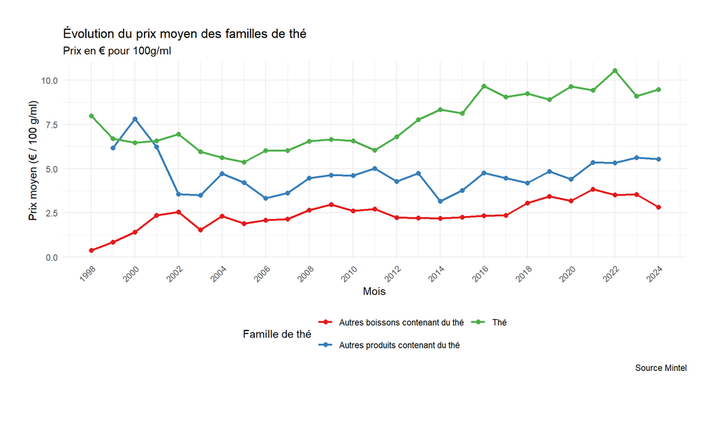

```r
library(ggplot2)
library(dplyr)
library(lubridate) # Pour la gestion des dates

# 1. Préparation des données (par famille et par mois)
prix_par_mois_famille <- df_clean %>%
  filter(!is.na(Prix_corrige),
         Prix_corrige <=50,
         `Famille thé` != "Thé prêt à boire",
         `Famille thé` != "Aliments pour animaux contenant du thé") %>%
  mutate(
    last_year = (year == max(year)),
    label = if_else(last_year, `Famille thé`, NA_character_)
  ) %>%
  group_by(year, `Famille thé`) %>%
  summarise(Prix_moyen = mean(Prix_corrige), .groups = 'drop')

# 2. Visualisation avec courbes par famille
ggplot(prix_par_mois_famille, aes(x = year, y = Prix_moyen, color = `Famille thé`)) +
  geom_line(size = 1) +
  geom_point(size = 2) +
  scale_color_brewer(palette = "Set1") + # Palette de couleurs distinctes
  scale_x_continuous(breaks = seq(min(df$year), max(df$year), by = 2)) +
  labs(title = "Évolution du prix moyen des familles de thé",
       subtitle = "Prix en € pour 100g/ml",
       x = "Mois",
       y = "Prix moyen (€ / 100 g/ml)",
       color = "Famille de thé",
       caption = "Source Mintel") +
  theme_minimal() +
  theme(axis.text.x = element_text(angle = 45, hjust = 1),
        legend.position = "bottom",
        plot.margin = margin(1, 1, 2, 1, "cm")) +
  guides(color = guide_legend(nrow = 2)) # Légende sur 2 lignes si nécessaire
```

```r
rm(prix_par_mois_famille)
```

### Focus sur la France

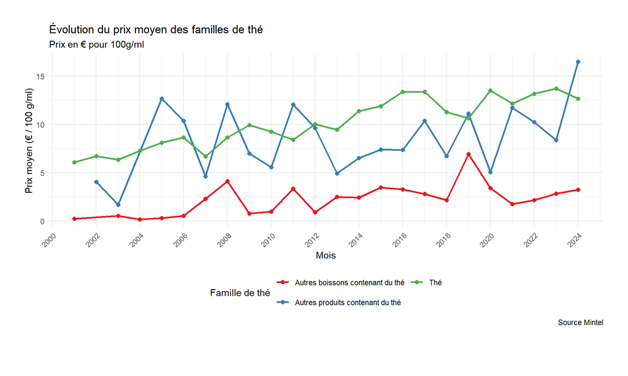

```r
library(ggplot2)
library(dplyr)
library(lubridate) # Pour la gestion des dates

# 1. Préparation des données (par famille et par mois)
prix_par_mois_famille <- df_clean %>%
  filter(!is.na(Prix_corrige),
         Market == "France",
         Prix_corrige <= 50,
         `Famille thé` != "Thé prêt à boire",
         `Famille thé` != "Aliments pour animaux contenant du thé") %>%
  mutate(
    last_year = (year == max(year)),
    label = if_else(last_year, `Famille thé`, NA_character_)
  ) %>%
  group_by(year, `Famille thé`) %>%
  summarise(Prix_moyen = mean(Prix_corrige), .groups = 'drop')

# 2. Visualisation avec courbes par famille
ggplot(prix_par_mois_famille, aes(x = year, y = Prix_moyen, color = `Famille thé`)) +
  geom_line(size = 1) +
  geom_point(size = 2) +
  scale_color_brewer(palette = "Set1") + # Palette de couleurs distinctes
  scale_x_continuous(breaks = seq(min(df$year), max(df$year), by = 2)) +
  labs(title = "Évolution du prix moyen des familles de thé",
       subtitle = "Prix en € pour 100g/ml",
       x = "Mois",
       y = "Prix moyen (€ / 100 g/ml)",
       color = "Famille de thé",
       caption = "Source Mintel") +
  theme_minimal() +
  theme(axis.text.x = element_text(angle = 45, hjust = 1),
        legend.position = "bottom",
        plot.margin = margin(1, 1, 2, 1, "cm")) +
  guides(color = guide_legend(nrow = 2)) # Légende sur 2 lignes si nécessaire
```

```r
rm(prix_par_mois_famille)
```

## 2. Statistiques Descriptives (suite)

### Claims Marketing les Plus Fréquents

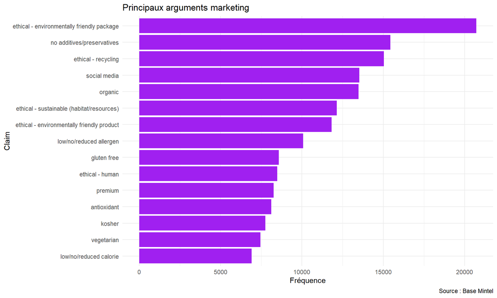

```r
# Extraction des claims individuels
claims <- df %>%
  filter(!is.na(`Positioning Claims`)) %>%
  unnest_tokens(claim, `Positioning Claims`, token = "regex", pattern = ",\\s*") %>%
  count(claim, sort = TRUE)

# Top 15 des claims les plus fréquents
claims %>%
  slice_max(n, n = 15) %>%
  ggplot(aes(x = reorder(claim, n), y = n)) +
  geom_col(fill = "purple") +
  coord_flip() +
  labs(title = "Principaux arguments marketing",
       x = "Claim",
       y = "Fréquence",
       caption = "Source : Base Mintel") +
  theme_minimal()
```